# Ford GoBike System Data Exploration

## by Heloa Silva

## Investigation Overview

In this investigation, I wanted to look at the characteristics of rides that could be used to understand the customer behavior. The main focus was on the durantion of the rides, user type and the dates which I extracted the month, year and weekday.

## Dataset Overview

There are information of the first semester of 2018 and 2019,  
total of 2.064.003 rides in the dataset with 17 features: duration_sec, start_time, end_time, start_station_id, start_station_name,  
start_station_latitude, start_station_longitude, end_station_id, end_station_name,  
end_station_latitude, end_station_longitude, bike_id, user_type, member_birth_year,  
member_gender, bike_share_for_all_trip, rental_access_method

## Share of User Type

In the pie chart we can notice that user type 'Subscriber' has the bigger share of the rides.  
Plan to investigate further if the average of duration it's also higher for the user type 'Subscriber'.

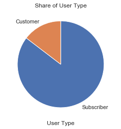

```python
# code for the pie chart using user_type variable
sorted_counts = df['user_type'].value_counts()

plt.xlabel('User Type')
plt.title('Share of User Type')
plt.pie(sorted_counts, labels = sorted_counts.index, startangle = 90,
        counterclock = False)
plt.show();
```

## Average of Rides per User Type

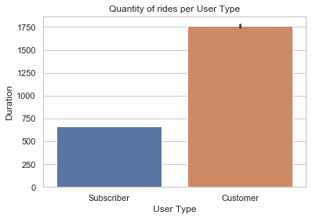

```python
# code for the bar chart using user_type with the duration variable
sb.barplot(data = df, x = 'user_type', y = 'duration_sec')
plt.ylabel('Duration')
plt.xlabel('User Type')
plt.title('Quantity of rides per User Type');
```

## Drill Down of User Type per Month

When we drill down the rides for user type into the months  
we can see that the user type 'Customer' has the higher quantity of seconds.

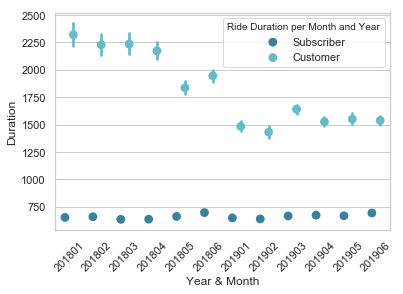

```python
# code for the bar chart using user_type with the duration variable
ax = sb.pointplot(data = df, x = 'start_time_year_month', y = 'duration_sec', hue = 'user_type',
                  dodge = 0.3, linestyles = "", palette='GnBu_d')
ax.legend(title = 'Ride Duration per Month and Year')
plt.ylabel('Duration')
plt.xlabel('Year & Month')
plt.xticks(rotation = 45);
```